# Recheck the correlation approach for ICC estimation

Author

Tzu-Yao Lin

Published

December 10, 2025

# 1 Setup

Load necessary packages.

```r
library(tidyverse)
theme_set(theme_bw() +
          theme(aspect.ratio = 1))
library(furrr)
plan(multisession, workers = 8)
library(irr)
library(psych)

set.seed(20251210)
```

Load a demo dataset from Sophie’s course. The following dataset comes from @bland1999. The researchers were interested in studying the reliability of systolic blood pressure measurements (mmHg) taken manually (i.e., by a human) and by a semi-automatic machine. The systolic blood pressure was recorded manually by two raters (J and R) and by the semi-automatic machine (S) at three consecutive occasions on 85 subjects. The 85 subjects were randomly taken in the general population.

- item: subject ID
- X1_J: first measurement taken by rater J
- X2_J: second measurement taken by rater J
- X3_J: third measurement taken by rater J

Then, the same variables are recorded for rater R (X1_R, X2_R, X3_R) and for the semi-automatic machine (X1_S, X2_S, X3_S)

```r
load("data/sbp.wide.rda")
skimr::skim(sbp.wide)
```

Data summary

| Name | sbp.wide |
| --- | --- |
| Number of rows | 85 |
| Number of columns | 10 |
| _______________________ |  |
| Column type frequency: |  |
| numeric | 10 |
| ________________________ |  |
| Group variables | None |

**Variable type: numeric**

| skim_variable | n_missing | complete_rate | mean | sd | p0 | p25 | p50 | p75 | p100 | hist |
| --- | --- | --- | --- | --- | --- | --- | --- | --- | --- | --- |
| item | 0 | 1 | 43.00 | 24.68 | 1 | 22 | 43 | 64 | 85 | ▇▇▇▇▇ |
| X1_J | 0 | 1 | 128.54 | 31.47 | 76 | 108 | 120 | 146 | 220 | ▃▇▃▂▁ |
| X1_R | 0 | 1 | 128.26 | 31.26 | 76 | 106 | 118 | 146 | 220 | ▅▇▅▂▁ |
| X1_S | 0 | 1 | 144.84 | 33.53 | 77 | 121 | 139 | 162 | 228 | ▂▇▆▂▂ |
| X2_J | 0 | 1 | 127.29 | 31.54 | 74 | 108 | 118 | 144 | 220 | ▃▇▅▂▁ |
| X2_R | 0 | 1 | 127.60 | 31.22 | 76 | 108 | 118 | 142 | 220 | ▅▇▅▂▁ |
| X2_S | 0 | 1 | 142.74 | 32.82 | 88 | 119 | 132 | 160 | 228 | ▃▇▅▂▂ |
| X3_J | 0 | 1 | 126.39 | 30.52 | 76 | 106 | 122 | 140 | 228 | ▆▇▃▁▁ |
| X3_R | 0 | 1 | 126.11 | 30.20 | 76 | 106 | 120 | 138 | 226 | ▅▇▃▁▁ |
| X3_S | 0 | 1 | 141.51 | 31.53 | 88 | 124 | 135 | 154 | 226 | ▃▇▃▂▁ |

# 2 Recheck the correlation approach

## 2.1 Case 1: One-way ANOVA (Classcial Test Theory)

Subject: $i = 1, \dots, N$, Raters: $j = 1, \dots, M$ which are nested within subjects.

$$Y_{(j)i} = T_i + E_{(j)i} = \mu + S_i + E_{(j)i}$$

where

- $T_i = E_{J}[Y_{(j)i}] = \mu + S_i \sim N(0, \sigma_S^2)$
- $E_{(j)i} \sim N(0, \sigma_E^2)$

### 2.1.1 A simple example

Let me generate a simulated data

```r
N <- 1000
M <- 50
mu <- 1
sigma_S <- 3
sigma_E <- 5

gen_one_way_anova <- function(N, M, mu, sigma_S, sigma_E){
  S <- outer(rnorm(N, 0, sigma_S), rep(1, M))
  E <- matrix(rnorm(N * M, 0, sigma_E), nrow = N)
  Y <- mu + S + E

  return(Y)
}

Y <- gen_one_way_anova(N, M, mu, sigma_S, sigma_E)
Y[1:5, 1:5] |> round(2)
```

```
      [,1]  [,2]  [,3]  [,4]  [,5]
[1,]  3.29  1.08  4.45  3.63  0.75
[2,] -7.69  8.49  3.72  1.41 -3.45
[3,] 12.21 -1.26 11.64 15.03  8.82
[4,] -2.60  5.92  1.82  2.88  3.63
[5,]  1.44  2.60  8.86 -4.69 -0.07
```

**Population reliability:**

ICC(1):

$$\begin{split}
\rho_{YY'}
&= Cor(y_{ij}, y_{ij'}) \\
&= \frac{\sigma_S^2}{\sigma_S^2 + \sigma_E^2} \\
&= ICC(1)
\end{split}$$

ICC(k):

$$\begin{split}
\rho_{\bar{Y}\bar{Y}'}
&= Cor(\bar{y}_{i\cdot}, \bar{y}_{i\cdot'}) \\
&=\frac{\sigma_S^2}{\sigma_S^2 + \sigma_E^2 / M} \\
&= ICC(k = M)
\end{split}$$

```r
ICC_1 <- sigma_S^2 / (sigma_S^2 + sigma_E^2)
ICC_1
```

```
[1] 0.2647059
```

```r
ICC_k <- sigma_S^2 / (sigma_S^2 + sigma_E^2 / M)
ICC_k
```

```
[1] 0.9473684
```

**Sample reliability (estimator):**

1. ICC-based estimates

$$ICC_s(1) = \frac{MSBS - MSWS}{MSBS + (M - 1) MSWS}$$

$$ICC_s(k) = \frac{MSBS - MSWS}{MSBS}$$

It can be done by the `irr` package.

```r
icc(Y, model = "oneway", unit = "single")
```

```
 Single Score Intraclass Correlation

   Model: oneway
   Type : consistency

   Subjects = 1000
     Raters = 50
     ICC(1) = 0.266

 F-Test, H0: r0 = 0 ; H1: r0 > 0
F(999,49000) = 19.1 , p = 0

 95%-Confidence Interval for ICC Population Values:
  0.249 < ICC < 0.285
```

```r
icc(Y, model = "oneway", unit = "average")
```

```
 Average Score Intraclass Correlation

   Model: oneway
   Type : consistency

   Subjects = 1000
     Raters = 50
    ICC(50) = 0.948

 F-Test, H0: r0 = 0 ; H1: r0 > 0
F(999,49000) = 19.1 , p = 0

 95%-Confidence Interval for ICC Population Values:
  0.943 < ICC < 0.952
```

2. Cor-based estimates

**Note**

For the full model detailed and the correlation procedure, please check the handwritten note.

```r
icc1_cor <- function(Y,
                     unit = c("single", "average"),
                     rep_size = 1,
                     parallel = TRUE){
  unit <- match.arg(unit)
  N <- nrow(Y)
  M <- ncol(Y)

  get_icc1_cor <- function(i) {
    if (unit == "single") {

      selected_j1j2 <- replicate(N, sample(1:M, 2, replace = FALSE))
      Y_j1 <- Y[cbind(1:N, selected_j1j2[1, ])]
      Y_j2 <- Y[cbind(1:N, selected_j1j2[2, ])]
      return(cor(Y_j1, Y_j2))

    } else if (unit == "average") {

      selected_j1s <- replicate(N, sample(1:M, M, replace = TRUE))
      selected_j2s <- replicate(N, sample(1:M, M, replace = TRUE))
      Y_j1s_matrix <- matrix(Y[cbind(rep(1:N, each = M), as.vector(selected_j1s))], nrow = N, byrow = TRUE)
      Y_j2s_matrix <- matrix(Y[cbind(rep(1:N, each = M), as.vector(selected_j2s))], nrow = N, byrow = TRUE)
      Y_j1s_mean <- rowMeans(Y_j1s_matrix, na.rm = TRUE)
      Y_j2s_mean <- rowMeans(Y_j2s_matrix, na.rm = TRUE)
      return(cor(Y_j1s_mean, Y_j2s_mean))

    }
  }

  if (parallel) {
    icc1 <- future_map_dbl(seq_len(rep_size), get_icc1_cor,
                   .options = furrr_options(seed = TRUE))
  } else {
    icc1 <- map_dbl(seq_len(rep_size), get_icc1_cor)
  }

  return(icc1)
}
```

```r
icc1_cor(Y, "single")
```

```
[1] 0.2245925
```

However, this calculation does not use all the data information because of the random sampling. Therfore, we can repeat this procedure many times to get the cor-based estimates and then take the average.

```r
icc1_cor_rep <- icc1_cor(Y, "single", rep_size = 1000)
mean(icc1_cor_rep)
```

```
[1] 0.2654116
```

```r
quantile(icc1_cor_rep, c(0.025, 0.975))
```

```
     2.5%     97.5%
0.2117552 0.3220908
```

```r
# icc1_cor_rep <- icc1_cor(Y, "single", boot_size = 10000)
# mean(icc1_cor_rep)
# quantile(icc1_cor_rep, c(0.025, 0.975))
```

I’m not fully sure how to deal with the correlation for the average scores …

```r
icc1_cor_rep <- icc1_cor(Y, "average", rep_size = 1000)
mean(icc1_cor_rep)
```

```
[1] 0.9512579
```

```r
quantile(icc1_cor_rep, c(0.025, 0.975))
```

```
     2.5%     97.5%
0.9467432 0.9556596
```

```r
# icc1_cor_rep <- icc1_cor(Y, "average", boot_size = 10000)
# mean(icc1_cor_rep)
# quantile(icc1_cor_rep, c(0.025, 0.975))
```

### 2.1.2 Real data example

Here, let’s re-analyze the systolic blood pressure data for an example.

```r
sbp_S <- sbp.wide |>
  select(ends_with("_S")) |>
  as.matrix()

icc(sbp_S, model = "oneway", unit = "single")
```

```
 Single Score Intraclass Correlation

   Model: oneway
   Type : consistency

   Subjects = 85
     Raters = 3
     ICC(1) = 0.922

 F-Test, H0: r0 = 0 ; H1: r0 > 0
  F(84,170) = 36.5 , p = 5.14e-77

 95%-Confidence Interval for ICC Population Values:
  0.891 < ICC < 0.946
```

```r
icc(sbp_S, model = "oneway", unit = "average")
```

```
 Average Score Intraclass Correlation

   Model: oneway
   Type : consistency

   Subjects = 85
     Raters = 3
     ICC(3) = 0.973

 F-Test, H0: r0 = 0 ; H1: r0 > 0
  F(84,170) = 36.5 , p = 5.14e-77

 95%-Confidence Interval for ICC Population Values:
  0.961 < ICC < 0.981
```

```r
icc1_cor_rep <- icc1_cor(sbp_S, "single", rep_size = 1000)
mean(icc1_cor_rep)
```

```
[1] 0.9235867
```

```r
quantile(icc1_cor_rep, c(0.025, 0.975))
```

```
     2.5%     97.5%
0.8982544 0.9483084
```

```r
icc1_cor_rep <- icc1_cor(sbp_S, "average", rep_size = 1000)
mean(icc1_cor_rep)
```

```
[1] 0.9822039
```

```r
quantile(icc1_cor_rep, c(0.025, 0.975))
```

```
     2.5%     97.5%
0.9688650 0.9903992
```

### 2.1.3 Simulation

To give a more comprehensive comparison between the ICC-based and cor-based approaches, I conduct a simulation study under various conditions.

```r
run_case1_sim <- function(N, M, mu, sigma_S, sigma_E) {

  # Generate the data for this single case
  Y <- gen_one_way_anova(N, M, mu, sigma_S, sigma_E)

  # Run the analyses
  icc_1_output <- icc(Y, model = "oneway", unit = "single")
  icc_k_output <- icc(Y, model = "oneway", unit = "average")
  cor_1_output <- icc1_cor(Y, unit = "single", rep_size = 1000, parallel = FALSE)
  cor_k_output <- icc1_cor(Y, unit = "average", rep_size = 1000, parallel = FALSE)

  # Extract and summarize the results immediately
  # Return a single tibble or list with only the essential results
  tibble(
    icc_1 = icc_1_output$value,
    icc_1_l = icc_1_output$lbound,
    icc_1_u = icc_1_output$ubound,
    icc_k = icc_k_output$value,
    icc_k_l = icc_k_output$lbound,
    icc_k_u = icc_k_output$ubound,
    cor_1 = mean(cor_1_output),
    cor_1_l = quantile(cor_1_output, 0.025),
    cor_1_u = quantile(cor_1_output, 0.975),
    cor_k = mean(cor_k_output),
    cor_k_l = quantile(cor_k_output, 0.025),
    cor_k_u = quantile(cor_k_output, 0.975)
  )
}
```

```r
N <- c(30, 100, 1000)
M <- c(5, 30, 50)
sigma_E <- c(1, 3, 5)
sigma_SE_ratio <- c(0.5, 1, 2)

case1_sim <-
  expand_grid(
    N = N,
    M = M,
    sigma_E = sigma_E,
    sigma_SE_ratio = sigma_SE_ratio
  ) |>
  mutate(
    sigma_S = sigma_SE_ratio * sigma_E,
    ICC_1 = sigma_S^2 / (sigma_S^2 + sigma_E^2),
    ICC_k = sigma_S^2 / (sigma_S^2 + sigma_E^2 / M),
    est_results = future_pmap(
      list(N, M, mu = 1, sigma_S, sigma_E),
      run_case1_sim,
      .options = furrr_options(seed = TRUE)
    )
  ) |>
  unnest(est_results)

write_rds(case1_sim, "data/case1_sim.rds")
```

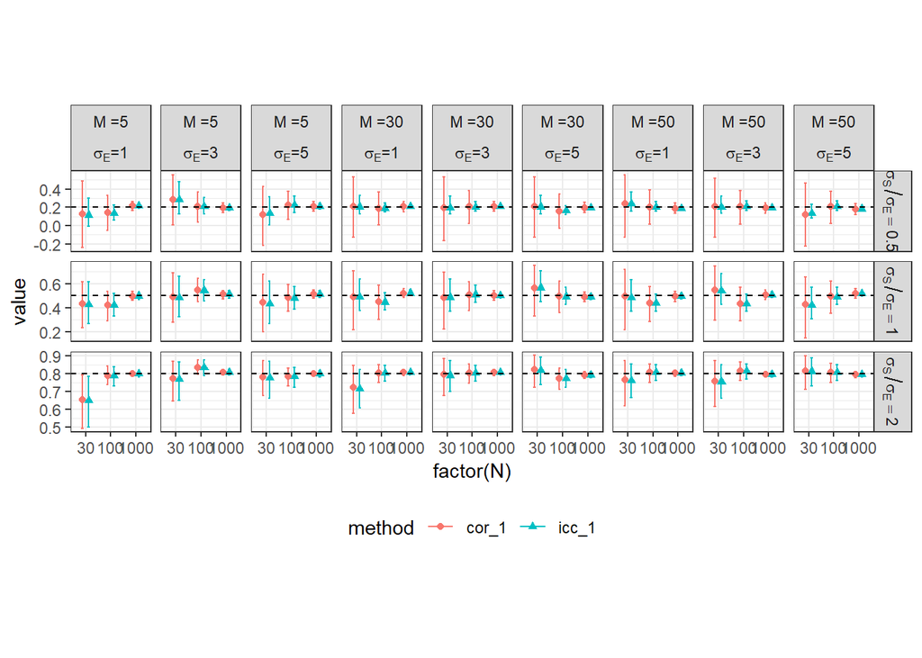

Figure 1: Comparison between ICC(1) and cor-based estimates under various simulation conditions.

```r
case1_sim |>
  select(N, M, sigma_E, sigma_SE_ratio, sigma_S,
         ICC_1, icc_1, icc_1_l, icc_1_u, cor_1, cor_1_l, cor_1_u) |>
  pivot_longer(cols = c(icc_1, cor_1),
               names_to = "method",
               values_to = "value") |>
  ggplot(aes(x = factor(N), y = value, color = method)) +
    geom_point(aes(shape = method),
               position = position_dodge(width = 0.5)) +
    geom_errorbar(aes(ymin = ifelse(method == "icc_1", icc_1_l, cor_1_l),
                      ymax = ifelse(method == "icc_1", icc_1_u, cor_1_u)),
                  width = 0.2,
                  position = position_dodge(width = 0.5)) +
    geom_hline(aes(yintercept = ICC_1), linetype = "dashed") +
    facet_grid(sigma_SE_ratio ~ M +sigma_E,
               scales = "free_y",
               labeller = label_bquote(rows = sigma[S]/sigma[E] == .(sigma_SE_ratio),
                                       cols = atop(paste("M =", .(M)),
                                                   paste(sigma[E], "=", .(sigma_E))))) +
    theme(legend.position = "bottom")
```

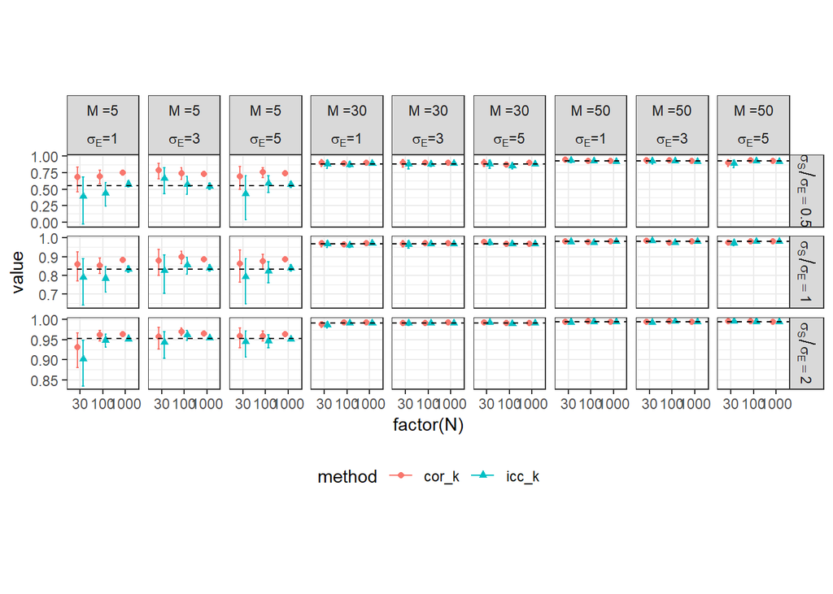

Figure 2: Comparison between ICC(k) and cor-based estimates under various simulation conditions.

```r
case1_sim |>
  select(N, M, sigma_E, sigma_SE_ratio, sigma_S,
         ICC_k, icc_k, icc_k_l, icc_k_u, cor_k, cor_k_l, cor_k_u) |>
  pivot_longer(cols = c(icc_k, cor_k),
               names_to = "method",
               values_to = "value") |>
  ggplot(aes(x = factor(N), y = value, color = method)) +
    geom_point(aes(shape = method),
               position = position_dodge(width = 0.5)) +
    geom_errorbar(aes(ymin = ifelse(method == "icc_k", icc_k_l, cor_k_l),
                      ymax = ifelse(method == "icc_k", icc_k_u, cor_k_u)),
                  width = 0.2,
                  position = position_dodge(width = 0.5)) +
    geom_hline(aes(yintercept = ICC_k), linetype = "dashed") +
    facet_grid(sigma_SE_ratio ~ M +sigma_E,
               scales = "free_y",
               labeller = label_bquote(rows = sigma[S]/sigma[E] == .(sigma_SE_ratio),
                                       cols = atop(paste("M =", .(M)),
                                                   paste(sigma[E], "=", .(sigma_E))))) +
    theme(legend.position = "bottom")
```

It looks pretty fine for ICC(1). However, for ICC(k), the cor-based approach seems to slightly overestimate the true reliability when the number of raters is small.

I’m not sure why this happens … Maybe the simulation procedure is not appropriate for the average scores?

## 2.2 Case 2: Two-way random effect ANOVA

Subject: $i = 1, \dots, N$, Raters: $j = 1, \dots, M$. Subjects and raters are crossed with each other.

$$Y_{ij} = \mu + S_i + R_j + (SR_{ij} + E_{ij}^*) = \mu + S_i + R_j + E_{ij}$$

where

- $S_i \sim N(0, \sigma_S^2)$
- $R_j \sim N(0, \sigma_R^2)$
- $E_{ij} \sim N(0, \sigma_E^2)$

### 2.2.1 A simple example

Let me generate a simulated data, agian.

```r
N <- 1000
M <- 50
mu <- 1
sigma_S <- 2
sigma_R <- 6
sigma_E <- 3

gen_two_way_random_anova <- function(N, M, mu, sigma_S, sigma_R, sigma_E){
  S <- outer(rnorm(N, 0, sigma_S), rep(1, M))
  R <- outer(rep(1, N), rnorm(M, 0, sigma_R))
  E <- matrix(rnorm(N * M, 0, sigma_E), nrow = N)
  Y <- mu + S + R + E

  return(Y)
}

Y <- gen_two_way_random_anova(N, M, mu, sigma_S, sigma_R, sigma_E)
Y[1:5, 1:5] |> round(2)
```

```
      [,1]  [,2]  [,3] [,4]  [,5]
[1,]  7.54 -5.85  3.73 4.83 -3.32
[2,]  0.30 -5.90 -2.14 7.11  4.49
[3,]  7.07 -9.42 -2.13 7.32  3.90
[4,]  7.89 -3.28  7.11 2.62  4.66
[5,] 12.17 -6.46 -3.50 5.13  0.96
```

**Population reliaiblity:**

ICC(A, 1) and ICC(A, k)
$$\begin{split}
\rho_{YY'}
&= Cor(y_{ij}, y_{ij'}) \\
&= \frac{\sigma_S^2}{\sigma_S^2 + \sigma_R^2 +\sigma_E^2} \\
&= ICC(A, 1)
\end{split}$$

$$\begin{split}
\rho_{\bar{Y}\bar{Y}'}
&= Cor(\bar{y}_{i\cdot}, y_{\bar{i}_\cdot'}) \\
&= \frac{\sigma_S^2}{\sigma_S^2 + \sigma_R^2 / M +\sigma_E^2 / M} \\
&= ICC(A, k=M)
\end{split}$$

ICC(C, 1) and ICC(C, k)

$$\begin{split}
Cor(y_{ij}, y_{ij'} \mid j, j')
&= \frac{\sigma_S^2}{\sigma_S^2 + \sigma_E^2} \\
&= ICC(C, 1)
\end{split}$$

$$\begin{split}
Cor(\bar{y}_{i\cdot}, \bar{y}_{i\cdot'} \mid \forall j, \forall j')
&= \frac{\sigma_S^2}{\sigma_S^2 + \sigma_E^2 / M} \\
&= ICC(C, k = M)
\end{split}$$

```r
ICC_A1 <- sigma_S^2 / (sigma_S^2 + sigma_R^2 + sigma_E^2)
ICC_A1
```

```
[1] 0.08163265
```

```r
ICC_Ak <- sigma_S^2 / (sigma_S^2 + sigma_R^2 / M + sigma_E^2 / M)
ICC_Ak
```

```
[1] 0.8163265
```

```r
ICC_C1 <- sigma_S^2 / (sigma_S^2 + sigma_E^2)
ICC_C1
```

```
[1] 0.3076923
```

```r
ICC_Ck <- sigma_S^2 / (sigma_S^2 + sigma_E^2 / M)
ICC_Ck
```

```
[1] 0.9569378
```

**Sample reliability (estimator):**

1. ICC-based estimates

$$ICC(A, 1) = \frac{MSBS - MSE}{MSBS + (M-1)MSE + M(MSBM - MSE)/N}$$

$$ICC(A, k) = \frac{MSBS - MSE}{MSBS + M(MSBM - MSE)/N}$$

$$ICC(C, 1) = \frac{MSBS - MSE}{MSBS + (M-1)MSE}$$

$$ICC(C, k) - \frac{MSBS - MSE}{MSBS}$$

```r
icc(Y, model = "twoway", type = "agreement", unit = "single")
```

```
 Single Score Intraclass Correlation

   Model: twoway
   Type : agreement

   Subjects = 1000
     Raters = 50
   ICC(A,1) = 0.112

 F-Test, H0: r0 = 0 ; H1: r0 > 0
 F(999,100) = 24.2 , p = 1.92e-49

 95%-Confidence Interval for ICC Population Values:
  0.083 < ICC < 0.143
```

```r
icc(Y, model = "twoway", type = "agreement", unit = "average")
```

```
 Average Score Intraclass Correlation

   Model: twoway
   Type : agreement

   Subjects = 1000
     Raters = 50
  ICC(A,50) = 0.863

 F-Test, H0: r0 = 0 ; H1: r0 > 0
F(999,92.2) = 24.2 , p = 9.92e-46

 95%-Confidence Interval for ICC Population Values:
  0.817 < ICC < 0.894
```

```r
icc(Y, model = "twoway", type = "consistency", unit = "single")
```

```
 Single Score Intraclass Correlation

   Model: twoway
   Type : consistency

   Subjects = 1000
     Raters = 50
   ICC(C,1) = 0.317

 F-Test, H0: r0 = 0 ; H1: r0 > 0
F(999,48951) = 24.2 , p = 0

 95%-Confidence Interval for ICC Population Values:
  0.298 < ICC < 0.338
```

```r
icc(Y, model = "twoway", type = "consistency", unit = "average")
```

```
 Average Score Intraclass Correlation

   Model: twoway
   Type : consistency

   Subjects = 1000
     Raters = 50
  ICC(C,50) = 0.959

 F-Test, H0: r0 = 0 ; H1: r0 > 0
F(999,48951) = 24.2 , p = 0

 95%-Confidence Interval for ICC Population Values:
  0.955 < ICC < 0.962
```

2. Cor-based estimates

**Note**

Check the handwritten note.

```r
icc2_cor <- function(Y,
                     type = c("agreement", "consistency"),
                     unit = c("single", "average"),
                     rep_size = 1,
                     parallel = TRUE){
    type <- match.arg(type)
    unit <- match.arg(unit)
    N <- nrow(Y)
    M <- ncol(Y)

    get_icc2_cor <- function(i) {
    if (type == "agreement") {
      if (unit == "single") { # ICC(A, 1)

        selected_j1j2 <- replicate(N, sample(1:M, 2, replace = FALSE))
        Y_j1 <- Y[cbind(1:N, selected_j1j2[1, ])]
        Y_j2 <- Y[cbind(1:N, selected_j1j2[2, ])]
        return(cor(Y_j1, Y_j2))

      } else if (unit == "average") { # ICC(A, k)

        selected_j1s <- replicate(N, sample(1:M, M, replace = TRUE))
        selected_j2s <- replicate(N, sample(1:M, M, replace = TRUE))
        Y_j1s_matrix <- matrix(Y[cbind(rep(1:N, each = M), as.vector(selected_j1s))], nrow = N, byrow = TRUE)
        Y_j2s_matrix <- matrix(Y[cbind(rep(1:N, each = M), as.vector(selected_j2s))], nrow = N, byrow = TRUE)
        Y_j1s_mean <- rowMeans(Y_j1s_matrix, na.rm = TRUE)
        Y_j2s_mean <- rowMeans(Y_j2s_matrix, na.rm = TRUE)
        return(cor(Y_j1s_mean, Y_j2s_mean))

      }
    } else if (type == "consistency") { # ICC(C, 1)
        if (unit == "single") {

        selected_j1j2 <- sample(1:M, 2, replace = FALSE)
        Y_j1 <- Y[cbind(1:N, selected_j1j2[1])]
        Y_j2 <- Y[cbind(1:N, selected_j1j2[2])]
        return(cor(Y_j1, Y_j2))

      } else if (unit == "average") { # ICC(C, k)

        selected_j1s <- sample(1:M, M, replace = TRUE)
        selected_j2s <- sample(1:M, M, replace = TRUE)
        Y_j1s_matrix <- matrix(Y[cbind(rep(1:N, each = M), selected_j1s)], nrow = N, byrow = TRUE)
        Y_j2s_matrix <- matrix(Y[cbind(rep(1:N, each = M), selected_j2s)], nrow = N, byrow = TRUE)
        Y_j1s_mean <- rowMeans(Y_j1s_matrix, na.rm = TRUE)
        Y_j2s_mean <- rowMeans(Y_j2s_matrix, na.rm = TRUE)
        return(cor(Y_j1s_mean, Y_j2s_mean))

      }
    }
  }

  if (parallel) {
    icc2 <- future_map_dbl(seq_len(rep_size), get_icc2_cor,
                    .options = furrr_options(seed = TRUE))
  } else {
    icc2 <- map_dbl(seq_len(rep_size), get_icc2_cor)
  }

  return(icc2)
}
```

```r
icc2_cor_rep <- icc2_cor(Y, type = "agreement", unit = "single", rep_size =1000)
mean(icc2_cor_rep)
```

```
[1] 0.1012071
```

```r
quantile(icc2_cor_rep, c(0.025, 0.975))
```

```
      2.5%      97.5%
0.04153139 0.15694169
```

```r
icc2_cor_rep <- icc2_cor(Y, type = "agreement", unit = "average", rep_size = 1000)
mean(icc2_cor_rep)
```

```
[1] 0.8697179
```

```r
quantile(icc2_cor_rep, c(0.025, 0.975))
```

```
     2.5%     97.5%
0.8577917 0.8809269
```

```r
icc2_cor_rep <- icc2_cor(Y, type = "consistency", unit = "single", rep_size =1000)
mean(icc2_cor_rep)
```

```
[1] 0.3179143
```

```r
quantile(icc2_cor_rep, c(0.025, 0.975))
```

```
     2.5%     97.5%
0.2643030 0.3663178
```

```r
icc2_cor_rep <- icc2_cor(Y, type = "consistency", unit = "average", rep_size = 1000)
mean(icc2_cor_rep)
```

```
[1] 0.9608405
```

```r
quantile(icc2_cor_rep, c(0.025, 0.975))
```

```
     2.5%     97.5%
0.9454194 0.9751013
```

### 2.2.2 Real data example

```r
icc(sbp_S, model = "twoway", type = "agreement", unit = "single")
```

```
 Single Score Intraclass Correlation

   Model: twoway
   Type : agreement

   Subjects = 85
     Raters = 3
   ICC(A,1) = 0.922

 F-Test, H0: r0 = 0 ; H1: r0 > 0
  F(84,164) = 37.3 , p = 1.81e-75

 95%-Confidence Interval for ICC Population Values:
  0.891 < ICC < 0.946
```

```r
icc(sbp_S, model = "twoway", type = "agreement", unit = "average")
```

```
 Average Score Intraclass Correlation

   Model: twoway
   Type : agreement

   Subjects = 85
     Raters = 3
   ICC(A,3) = 0.973

 F-Test, H0: r0 = 0 ; H1: r0 > 0
  F(84,163) = 37.3 , p = 2.43e-75

 95%-Confidence Interval for ICC Population Values:
  0.961 < ICC < 0.981
```

```r
icc(sbp_S, model = "twoway", type = "consistency", unit = "single")
```

```
 Single Score Intraclass Correlation

   Model: twoway
   Type : consistency

   Subjects = 85
     Raters = 3
   ICC(C,1) = 0.924

 F-Test, H0: r0 = 0 ; H1: r0 > 0
  F(84,168) = 37.3 , p = 4.48e-77

 95%-Confidence Interval for ICC Population Values:
  0.893 < ICC < 0.947
```

```r
icc(sbp_S, model = "twoway", type = "consistency", unit = "average")
```

```
 Average Score Intraclass Correlation

   Model: twoway
   Type : consistency

   Subjects = 85
     Raters = 3
   ICC(C,3) = 0.973

 F-Test, H0: r0 = 0 ; H1: r0 > 0
  F(84,168) = 37.3 , p = 4.48e-77

 95%-Confidence Interval for ICC Population Values:
  0.962 < ICC < 0.982
```

```r
icc2_cor_rep <- icc2_cor(sbp_S, type = "agreement", unit = "single", rep_size =1000)
mean(icc2_cor_rep)
```

```
[1] 0.9236612
```

```r
quantile(icc2_cor_rep, c(0.025, 0.975))
```

```
     2.5%     97.5%
0.8978416 0.9495662
```

```r
icc2_cor_rep <- icc2_cor(sbp_S, type = "agreement", unit = "average", rep_size = 1000)
mean(icc2_cor_rep)
```

```
[1] 0.9823895
```

```r
quantile(icc2_cor_rep, c(0.025, 0.975))
```

```
     2.5%     97.5%
0.9687184 0.9904785
```

```r
icc2_cor_rep <- icc2_cor(sbp_S, type = "consistency", unit = "single", rep_size =1000)
mean(icc2_cor_rep)
```

```
[1] 0.9248656
```

```r
quantile(icc2_cor_rep, c(0.025, 0.975))
```

```
     2.5%     97.5%
0.9072182 0.9466055
```

```r
icc2_cor_rep <- icc2_cor(sbp_S, type = "consistency", unit = "average", rep_size = 1000)
mean(icc2_cor_rep)
```

```
[1] 0.9827233
```

```r
quantile(icc2_cor_rep, c(0.025, 0.975))
```

```
     2.5%     97.5%
0.9364759 1.0000000
```

### 2.2.3 Simulation comparison

```r
run_case2_sim <- function(N, M, mu, sigma_S, sigma_R, sigma_E) {

  # Generate the data for this single case
  Y <- gen_two_way_random_anova(N, M, mu, sigma_S, sigma_R, sigma_E)

  # Run the analyses
  icc_A1_output <- icc(Y, model = "twoway", type = "agreement", unit = "single")
  icc_Ak_output <- icc(Y, model = "twoway", type = "agreement", unit = "average")
  icc_C1_output <- icc(Y, model = "twoway", type = "consistency", unit = "single")
  icc_Ck_output <- icc(Y, model = "twoway", type = "consistency", unit = "average")
  cor_A1_output <- icc2_cor(Y, type = "agreement", unit = "single", rep_size = 1000, parallel = FALSE)
  cor_Ak_output <- icc2_cor(Y, type = "agreement", unit = "average", rep_size = 1000, parallel = FALSE)
  cor_C1_output <- icc2_cor(Y, type = "consistency", unit = "single", rep_size = 1000, parallel = FALSE)
  cor_Ck_output <- icc2_cor(Y, type = "consistency", unit = "average", rep_size = 1000, parallel = FALSE)


  # Extract and summarize the results immediately
  # Return a single tibble or list with only the essential results
  tibble(
    icc_A1 = icc_A1_output$value,
    icc_A1_l = icc_A1_output$lbound,
    icc_A1_u = icc_A1_output$ubound,
    icc_Ak = icc_Ak_output$value,
    icc_Ak_l = icc_Ak_output$lbound,
    icc_Ak_u = icc_Ak_output$ubound,
    icc_C1 = icc_C1_output$value,
    icc_C1_l = icc_C1_output$lbound,
    icc_C1_u = icc_C1_output$ubound,
    icc_Ck = icc_Ck_output$value,
    icc_Ck_l = icc_Ck_output$lbound,
    icc_Ck_u = icc_Ck_output$ubound,
    cor_A1 = mean(cor_A1_output),
    cor_A1_l = quantile(cor_A1_output, 0.025),
    cor_A1_u = quantile(cor_A1_output, 0.975),
    cor_Ak = mean(cor_Ak_output),
    cor_Ak_l = quantile(cor_Ak_output, 0.025),
    cor_Ak_u = quantile(cor_Ak_output, 0.975),
    cor_C1 = mean(cor_C1_output),
    cor_C1_l = quantile(cor_C1_output, 0.025),
    cor_C1_u = quantile(cor_C1_output, 0.975),
    cor_Ck = mean(cor_Ck_output),
    cor_Ck_l = quantile(cor_Ck_output, 0.025),
    cor_Ck_u = quantile(cor_Ck_output, 0.975)
  )
}
```

```r
N <- c(30, 100, 1000)
M <- c(5, 30, 50)

sigma_E <- c(1, 3, 5)
sigma_SE_ratio <- c(0.5, 1, 2)
sigma_RE_ratio <- c(0.5, 1, 2)

case2_sim <-
  expand_grid(
    N = N,
    M = M,
    sigma_E = sigma_E,
    sigma_SE_ratio = sigma_SE_ratio,
    sigma_RE_ratio = sigma_RE_ratio
  ) |>
  mutate(
    sigma_S = sigma_SE_ratio * sigma_E,
    sigma_R = sigma_RE_ratio * sigma_E,
    ICC_A1 = sigma_S^2 / (sigma_S^2 + sigma_R^2 + sigma_E^2),
    ICC_Ak = sigma_S^2 / (sigma_S^2 + sigma_R^2 / M + sigma_E^2 / M),
    ICC_C1 = sigma_S^2 / (sigma_S^2 + sigma_E^2),
    ICC_Ck = sigma_S^2 / (sigma_S^2 + sigma_E^2 / M),
    est_results = future_pmap(
      list(N, M, mu = 1, sigma_S, sigma_R, sigma_E),
      run_case2_sim,
      .options = furrr_options(seed = TRUE)
    )
  ) |>
  unnest(est_results)

write_rds(case2_sim, "data/case2_sim.rds")
```

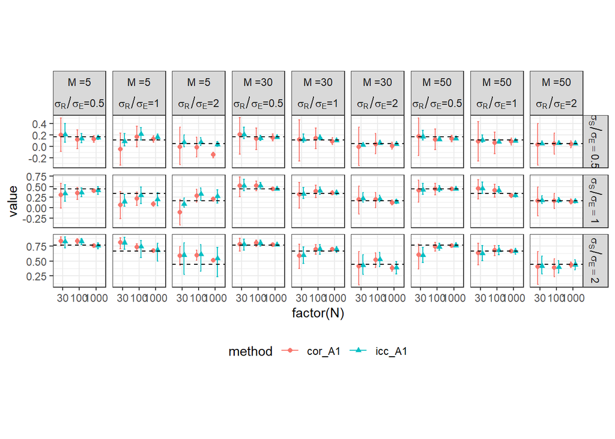

Figure 3: Comparison between ICC(A, 1) and cor-based estimates under various simulation conditions.

```r
case2_sim |>
  filter(sigma_E == 5) |>
  select(N, M, sigma_E, sigma_SE_ratio, sigma_RE_ratio,
         ICC_A1, icc_A1, icc_A1_l, icc_A1_u, cor_A1, cor_A1_l, cor_A1_u) |>
  pivot_longer(cols = c(icc_A1, cor_A1),
               names_to = "method",
               values_to = "value") |>
  ggplot(aes(x = factor(N), y = value, color = method)) +
    geom_point(aes(shape = method),
               position = position_dodge(width = 0.5)) +
    geom_errorbar(aes(ymin = ifelse(method == "icc_A1", icc_A1_l, cor_A1_l),
                      ymax = ifelse(method == "icc_A1", icc_A1_u, cor_A1_u)),
                  width = 0.2,
                  position = position_dodge(width = 0.5)) +
    geom_hline(aes(yintercept = ICC_A1), linetype = "dashed") +
    facet_grid(sigma_SE_ratio ~ M +sigma_RE_ratio,
               scales = "free_y",
               labeller = label_bquote(rows = sigma[S]/sigma[E] == .(sigma_SE_ratio),
                                       cols = atop(paste("M =", .(M)),
                                                   paste(sigma[R]/sigma[E], "=", .(sigma_RE_ratio))))) +
    theme(legend.position = "bottom")
```

**Warning**

There is a noticeable difference between icc-based and cor-based estimates, especially when $\sigma_R / \sigma_E$ is large.

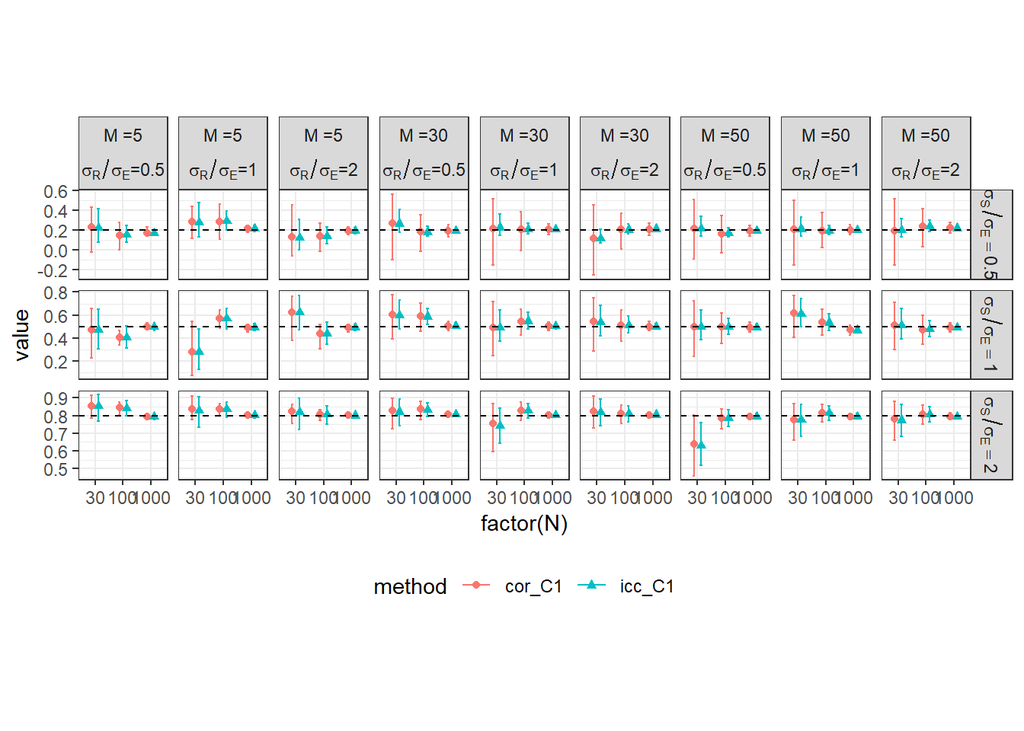

Figure 4: Comparison between ICC(C, 1) and cor-based estimates under various simulation conditions.

```r
case2_sim |>
  filter(sigma_E == 5) |>
  select(N, M, sigma_E, sigma_SE_ratio, sigma_RE_ratio,
         ICC_C1, icc_C1, icc_C1_l, icc_C1_u, cor_C1, cor_C1_l, cor_C1_u) |>
  pivot_longer(cols = c(icc_C1, cor_C1),
               names_to = "method",
               values_to = "value") |>
  ggplot(aes(x = factor(N), y = value, color = method)) +
    geom_point(aes(shape = method),
               position = position_dodge(width = 0.5)) +
    geom_errorbar(aes(ymin = ifelse(method == "icc_C1", icc_C1_l, cor_C1_l),
                      ymax = ifelse(method == "icc_C1", icc_C1_u, cor_C1_u)),
                  width = 0.2,
                  position = position_dodge(width = 0.5)) +
    geom_hline(aes(yintercept = ICC_C1), linetype = "dashed") +
    facet_grid(sigma_SE_ratio ~ M +sigma_RE_ratio,
               scales = "free_y",
               labeller = label_bquote(rows = sigma[S]/sigma[E] == .(sigma_SE_ratio),
                                       cols = atop(paste("M =", .(M)),
                                                   paste(sigma[R]/sigma[E], "=", .(sigma_RE_ratio))))) +
    theme(legend.position = "bottom")
```

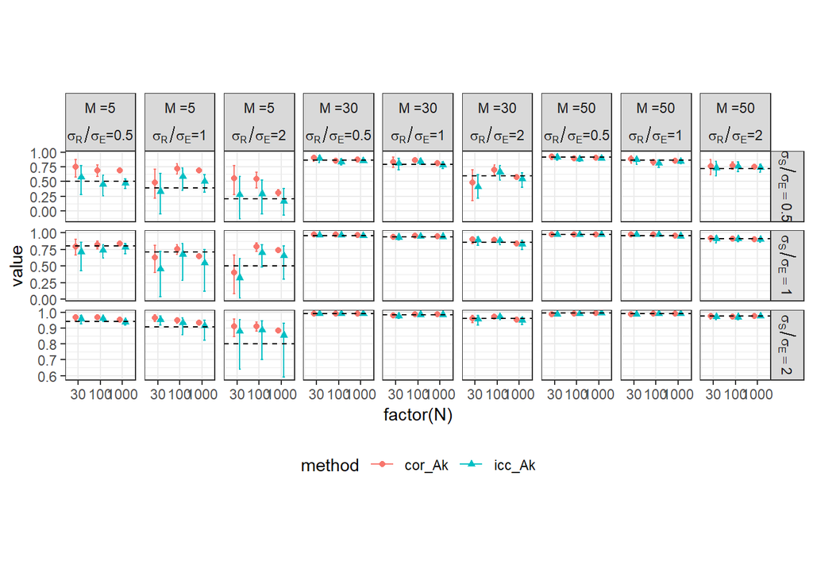

Figure 5: Comparison between ICC(A, k) and cor-based estimates under various simulation conditions.

```r
case2_sim |>
  filter(sigma_E == 5) |>
  select(N, M, sigma_E, sigma_SE_ratio, sigma_RE_ratio,
         ICC_Ak, icc_Ak, icc_Ak_l, icc_Ak_u, cor_Ak, cor_Ak_l, cor_Ak_u) |>
  pivot_longer(cols = c(icc_Ak, cor_Ak),
               names_to = "method",
               values_to = "value") |>
  ggplot(aes(x = factor(N), y = value, color = method)) +
    geom_point(aes(shape = method),
               position = position_dodge(width = 0.5)) +
    geom_errorbar(aes(ymin = ifelse(method == "icc_Ak", icc_Ak_l, cor_Ak_l),
                      ymax = ifelse(method == "icc_Ak", icc_Ak_u, cor_Ak_u)),
                  width = 0.2,
                  position = position_dodge(width = 0.5)) +
    geom_hline(aes(yintercept = ICC_Ak), linetype = "dashed") +
    facet_grid(sigma_SE_ratio ~ M +sigma_RE_ratio,
               scales = "free_y",
               labeller = label_bquote(rows = sigma[S]/sigma[E] == .(sigma_SE_ratio),
                                       cols = atop(paste("M =", .(M)),
                                                   paste(sigma[R]/sigma[E], "=", .(sigma_RE_ratio))))) +
    theme(legend.position = "bottom")
```

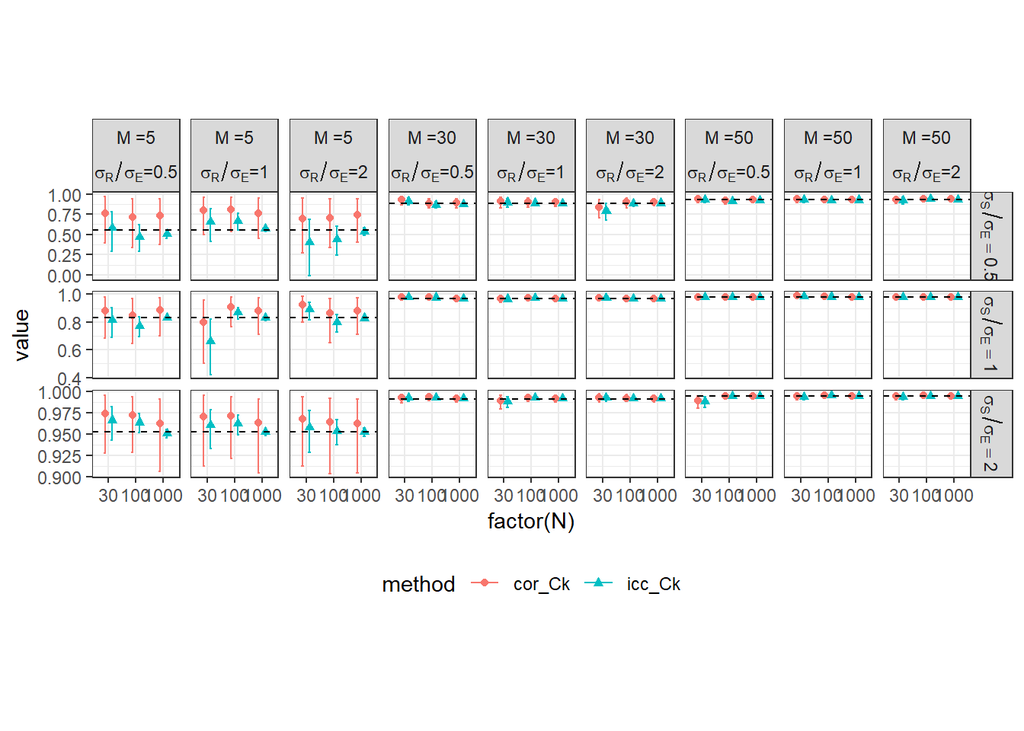

Figure 6: Comparison between ICC(C, k) and cor-based estimates under various simulation conditions.

```r
case2_sim |>
  filter(sigma_E == 5) |>
  select(N, M, sigma_E, sigma_SE_ratio, sigma_RE_ratio,
         ICC_Ck, icc_Ck, icc_Ck_l, icc_Ck_u, cor_Ck, cor_Ck_l, cor_Ck_u) |>
  pivot_longer(cols = c(icc_Ck, cor_Ck),
               names_to = "method",
               values_to = "value") |>
  ggplot(aes(x = factor(N), y = value, color = method)) +
    geom_point(aes(shape = method),
               position = position_dodge(width = 0.5)) +
    geom_errorbar(aes(ymin = ifelse(method == "icc_Ck", icc_Ck_l, cor_Ck_l),
                      ymax = ifelse(method == "icc_Ck", icc_Ck_u, cor_Ck_u)),
                  width = 0.2,
                  position = position_dodge(width = 0.5)) +
    geom_hline(aes(yintercept = ICC_Ck), linetype = "dashed") +
    facet_grid(sigma_SE_ratio ~ M +sigma_RE_ratio,
               scales = "free_y",
               labeller = label_bquote(rows = sigma[S]/sigma[E] == .(sigma_SE_ratio),
                                       cols = atop(paste("M =", .(M)),
                                                   paste(sigma[R]/sigma[E], "=", .(sigma_RE_ratio))))) +
    theme(legend.position = "bottom")
```

## 2.3 Case 3: Two-way mixed effect ANOVA

Subject: $i = 1, \dots, N$, Raters: $j = 1, \dots, M$. Subjects and raters are crossed with each other.

$$Y_{ij} = \mu + S_i + R_j + (SR_{ij} + E_{ij}^*) = \mu + S_i + R_j + E_{ij}$$

### 2.3.1 A simple example

Let me generate a simulated data, agian.

```r
N <- 1000
M <- 50
mu <- 1
sigma_S <- 4
theta_R <- 9
sigma_E <- 10


gen_two_way_mixed_anova <- function(N, M, mu, sigma_S, sigma_E){
  S <- outer(rnorm(N, 0, sigma_S), rep(1, M))
  R <- outer(rep(1, N), MASS::mvrnorm(M, mu = 0, Sigma = theta_R^2, empirical = TRUE)[, 1])
  E <- matrix(rnorm(N * M, 0, sigma_E), nrow = N)
  Y <- mu + S + R + E

  return(Y)
}

Y <- gen_two_way_mixed_anova(N, M, mu, sigma_S, sigma_E)
head(Y)
```

[output not shown]

[output cut: 41 more lines]

Note that to generate the fixed effect for raters, I use the `MASS::mvrnorm` function with the `empirical = TRUE` option to ensure that the generated raters have the desired variance.

…

## 2.4 Nested data

To be continuoued …